# Praca domowa 3

Ilona Bednarz

26.10.2018

## Wykres oryginalny

Poniżej znajduje się wybrany przeze mnie wykres pochodzący z artykułu zamieszczonego na portalu *300polityka.pl*. Wykres przedstawia wyniki sondaży przedwyborczych dotyczących wyborów samorządowych w Warszawie w 2018 roku. Obrazuje hipotetyczne poparcie, jakie uzyskaliby poszczególni politycy w wyborach na prezydenta Warszawy, jeśli startowaliby w nich podani kandydaci.

Wybrałam ten wykres, ponieważ został na nim popełniony szereg typowych błędów w sztuce wizualizacji danych, a także kilka nietypowych. Oczywiście przedstawienie danych, takich jak poparcie, na wykresie słupkowym jest dobrym pomysłem, ale sposób wykonania jest godny potępienia.

[figure not shown]

### Błędy popełnione na wykresie

1. Słupki i skala osi Y rozjeżdżają się w bardzo dziwnaczny sposób - np. słupek z wartością 12% znajduje się ponizej wartości 10% na skali osi Y, a słupek 2% jest poniżej zera! Pozostałe słupki również są źle położone w stosunku do skali. Jest to najpowazniejszy błąd, ponieważ zwyczajnie przekłamuje dane i może prowadzić do złego ich odczytania.
2. Kolejnym poważnym błędem jest wprowadzenie trzeciego wymiaru, mało tego, zastosowanie w nim perspektywy środkowej. Po pierwsze, nie ma sensu wprowadzać trzeciego wymiaru dla danych, które można z powodzeniem przedstawić na rysunku dwuwymiarowym. Po drugie, perspektywa środkowa uniemożliwia porównywanie słupków między sobą, gdyż słupkom niższym perspektywa ‘dodaje’ więcej wysokości niz tym wyższym, co zaburza relacje między nimi.
3. Oś pozioma nie jest pozioma, lecz nachylona pod kątem, co daje złudzenie, że słupki znajdujące się po lewej (czyli zaczepione wyżej) są wyższe niż w rzeczywistości.
4. Rolę podpisów osi X pełnią miniaturowe zdjęcia kandydatów, brakuje nazwisk, co części odbiorów całkowicie uniemożliwi odbiór wykresu.
5. Zdjęcia służące za podpis osi X nie są ułożone równolegle do tej osi, tylko w bez żadnego porządku. Przypisanie słupków do zdjęć zajmuje dłuższą chwilę (a nie powinno).
6. Białe podpisy słupków nie zawsze są widoczne, np. słupek z wartością 2.
7. Brak dużego i czytelnego tytułu wykresu oraz opisu osi Y.
8. Nie ma potrzeby używania różnych kolorów, jeśli nie kodują żadnej informacji.
9. Procenty nie sumuja się do 100, a do 99, co może być błędem wynikającym z zaokrąglenia do liczb całkowitych.

## Wykres poprawiony

Poniżej prezentuję wykres, na którym poprawiłam wszystkie wymienione wcześniej błędy.

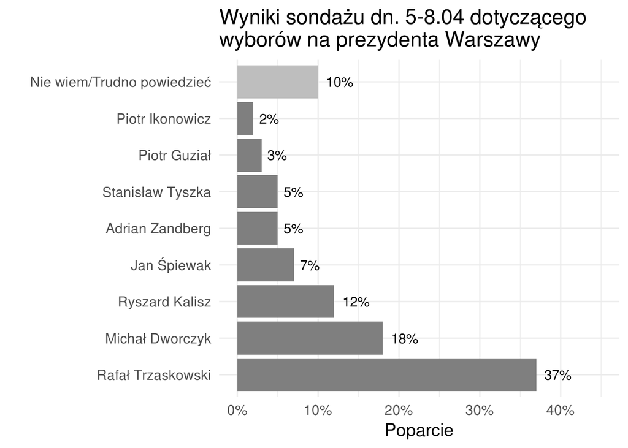

```r
ggplot(data = data, aes(x = Kandydat, y = Poparcie, label = paste0(Poparcie, "%"), fill = color)) +
  scale_fill_manual(values = c("grey50", "grey")) +
  geom_bar(stat = 'identity') +
  coord_flip() +
  scale_x_discrete(limits = order) +
  scale_y_continuous(limits = c(0, 45), labels = function(x) paste0(x, "%")) +
  geom_text(hjust = -0.3) +
  xlab('') +
  ggtitle('Wyniki sondażu dn. 5-8.04 dotyczącego\nwyborów na prezydenta Warszawy') +
  theme_minimal(base_size = 14) +
  theme(legend.position = 'none')
```